# Plotly, matplotlib, and mplexporter.

### Quickstart

Matplotlylib lets you convert matplotlib figures to beautiful D3js graphs drawn online with Plotly's [Python API](http://plot.ly/api/python). It's this easy...

```
>>> ## make an mpl figure ##
>>> import plotly.plotly as py
>>> py.plot_mpl(fig)
```

For install:

```bash
$ pip install plotly
```

### Intro

The mplexporter package is a recent development as a part of the [mpld3 project](http://mpld3.github.io/). The goal of mpld3 is to expand python's matplotlib use to the browser. By separating the matplotlib exporting and the actual graphic rendering, many renderers can now leverage the parsed matplotlib information. This makes the matplotlib-to-browser project easier for everyone. Nice.

Now, enter Plotly. Like keeping your data around? Want to share your plots and/or data online? We allow users to easily create and share interactive, publication-quality visualizations, right in a web browser. While Plotly's [Python API](https://plot.ly/api/python) gives users access to plotly directly, users may already have high-quality plots that they want to get online and share. Standing on the shoulders of the mplexporter, plotly is developing matplotlylib, a package that converts mpl figures to plotly figures with a simple call to `plot_mpl` or `iplot_mpl` (for plotting in IPython) . This function creates a JSON dictionary and sends it to be rendered on plotly with an option to put the resulting figure back into an IPython notebook.

If your data are important to you, they're important to us, and we'll help you share them with others.

For more infomation on using Plotly, you can check out our other [IPython notebooks](http://nbviewer.ipython.org/github/plotly/IPython-plotly/tree/master/). Or, just take a look at some practical uses from [Wired Science](http://www.wired.com/wiredscience/2014/02/much-real-olympic-gold-medal-cost/) and [The Washinton Post](http://www.washingtonpost.com/blogs/wonkblog/wp/2013/06/14/do-low-taxes-on-the-rich-leave-the-middle-class-with-lower-wages/). The most current version of matplotlylib can be found in the mpld3/matplotlylib repo.

A quick rundown of what this notebook covers. This is what matplotlylib supports so far.

- Imports
- Line Plots
- Subplots
- Annotations
- Resize
- Strip Style
- Bar Charts
- Scatter Plots
- Legends
- The Nitty Gritty (fine print)

### Imports

Let's start by calling the IPython 'magic' function for matplotlib so that plots show up inline. Next, we'll import all of the matplotlib tools necessary for creating the figures in this notebook.

```python
%matplotlib inline
import matplotlib.pyplot as plt # so we don't have to look at mpl's backend
import matplotlib.gridspec as gridspec # for subplots
import matplotlib.cm as cm # for fun-with-colors
import numpy as np
```

The only import required to render figures in plotly is the `iplot_mpl` function. We'll also fill in our creds here so that they're accessible later when we actually make the calls to plotly. You can use the `mpld3` username for now, or switch to your own Plotly username and api_key. Don't have a username? There's no better time than the [present](https://plot.ly/).

```python
import plotly.plotly as py
py.sign_in('mpld3','js5825bxqr')
```

### Start Plotting!

Simply make a figure and use the `fig_to_plotly` call.

```python
fig, ax = plt.subplots()
ax.plot([1,2,3])
ax.set_title('hello world... wide web')
py.iplot_mpl(fig, filename='hello mpl!', fileopt='overwrite')
```

[interactive chart not shown]

### Line Plots

Here we instantiate a matplotlib figure object and fill it with stuff we want to plot! IPython's matplotlib magic function will catch this code block and pop it inline when you 'shift-enter'.

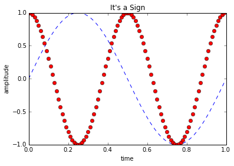

```python
fig1 = plt.figure()
x = np.arange(0,1.0,0.01)
y1 = np.sin(2*np.pi*x)
y2 = np.cos(4*np.pi*x)
ax = fig1.add_subplot(111)
ax.plot(x, y1, 'b--', label='sin')
ax.plot(x, y2, 'ro', label='cos')
ax.set_title("It's a Sign")
ax.set_xlabel('time')
ax.set_ylabel('amplitude')
```

Note how you can zoom, pan, autoscale, and see data points by hovering. The data you plotted is right there. If you want to modify the dataset, style, layout, or add notes, you can click the 'data and graph' link below the plot.

And again, if you have a [plotly profile](https://plot.ly/~RhettAllain/), you can save and share your awesome sinusoids with others.

```python
py.iplot_mpl(fig1, filename="a sign", fileopt='overwrite')
```

[interactive chart not shown]

### Subplots

But why have one axes object when you could have five!? Gridspec is a handy way to intuitively partition figure space into nice looking subplots. Here are just some simple line plots stretching over a 3x3 grid of plotting areas.

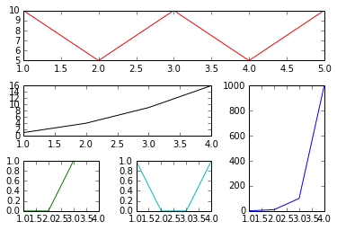

```python
fig2 = plt.figure() # matplotlib.figure.Figure obj
gs = gridspec.GridSpec(3, 3)
ax1 = fig2.add_subplot(gs[0,:])
ax1.plot([1,2,3,4,5], [10,5,10,5,10], 'r-')
ax2 = fig2.add_subplot(gs[1,:-1])
ax2.plot([1,2,3,4], [1,4,9,16], 'k-')
ax3 = fig2.add_subplot(gs[1:, 2])
ax3.plot([1,2,3,4], [1,10,100,1000], 'b-')
ax4 = fig2.add_subplot(gs[2,0])
ax4.plot([1,2,3,4], [0,0,1,1], 'g-')
ax5 = fig2.add_subplot(gs[2,1])
ax5.plot([1,2,3,4], [1,0,0,1], 'c-')
gs.update(wspace=0.5, hspace=0.5)
```

Again, if you're fond of matplotlib's syntax, or, you're just feeling like dipping your toes in the plotly pool for now, inserting a simpe `iplot_mpl` call sends the above figure to Plotly and it responds by sticking back into this notebook.

By default, matplotlib subplots don't have common axis elements and so the rendered plotly graphic will reflect this. However, as we've mentioned, plotly's all about sharing. You can check out the possibilities for anchoring different subplots to the same axis in the [plotly docs](https://plot.ly/api/python/docs/subplots) if you're trying to work through the API. Alternatively, you can use ploty's GUIs to change all of the plot's attributes--including axis sharing.

```python
py.iplot_mpl(fig2, filename='simple subplots', fileopt='overwrite')
```

[interactive chart not shown]

### Annotations

The matplotlib package supports multiple ways of getting annotations onto figures. These too get sent to plotly when you call `fig_to_plotly`. Let's start with some simple annotations that mark plot boundaries.

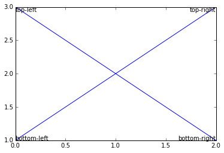

```python
fig3 = plt.figure()
ax = fig3.add_subplot(111)
ax.plot([1,2,3], 'b-')
ax.plot([3,2,1], 'b-')
ax.text(0.001, 0.999, 'top-left', transform=ax.transAxes, va='top', ha='left')
ax.text(0.001, 0.001, 'bottom-left', transform=ax.transAxes, va='baseline', ha='left')
ax.text(0.999, 0.999, 'top-right', transform=ax.transAxes, va='top', ha='right')
ax.text(0.999, 0.001, 'bottom-right', transform=ax.transAxes, va='baseline', ha='right')
```

Plotly will import these and anchor them appropriately to the plot, not to the data. You can pan and zoom in the following figure to check this. If you decide you don't want them anchored to the 'page', you can later switch them via the 'Notes' tab in Plotly.

```python
py.iplot_mpl(fig3, filename='annotations', fileopt='overwrite')
```

[interactive chart not shown]

Let's try a more interesting example. The following code creates a figure with a bunch of different line objects, each annotated with a text object that is anchored to data. Another annotation is anchored to the mpl axes objects so that it will remain in the top-left corner of the plot when you pan or zoom.

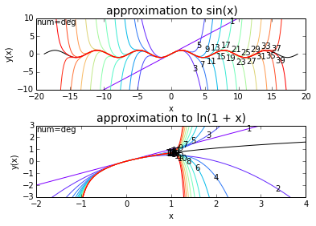

```python
gs = gridspec.GridSpec(2, 1)
fig4 = plt.figure()
ax1 = fig4.add_subplot(gs[0,0])
x = np.arange(-3, 3, 0.01)*2*np.pi
sin_x = np.sin(x)
ax1.plot(x, sin_x, 'k-', label='sin(x)')
num_lines = 20
colors = cm.rainbow(np.linspace(0, 1, num_lines))
for iii in range(0, num_lines):
    y = x
    for jjj in range(1, iii+1):
        sign = (-1)**jjj
        deg = 1+2*jjj
        y = np.add(y, sign*x**(deg)/np.math.factorial(deg))
    ct_h = int(len(x)/2)
    while abs(y[ct_h]) < 10:
        ct_h += 1
    ct_l = int(len(x)/2)
    while abs(y[ct_l]) < 10:
        ct_l -= 1
    x_plot = x[ct_l:ct_h+1]
    y_plot = y[ct_l:ct_h+1]
    ax1.plot(x_plot, y_plot, color=colors[iii], label='L{}'.format(iii))
    ax1.text(x_plot[-15], y_plot[-15], '{}'.format(1+2*iii), ha='center', va='center')
ax1.set_ylim(-10,10)
ax1.set_xlabel('x')
ax1.set_ylabel('y(x)')
ax1.set_title('approximation to sin(x)', size=14)
ax1.text(0.001, 0.999, 'num=deg', transform=ax1.transAxes, ha='left', va='top')

ax2 = fig4.add_subplot(gs[1,0])
x = np.arange(-5, 5, 0.01)
ax2.plot(np.arange(0.01, 5, 0.01),
         np.log(np.arange(0.01, 5, 0.01) + np.ones(len(np.arange(0.01, 5, 0.01)))),
         'k-', label='ln(x + 1)')
num_lines = 20
colors = cm.rainbow(np.linspace(0, 1, num_lines))
for iii in range(0, num_lines):
    y = x
    for jjj in range(1, iii+1):
        sign = (-1)**jjj
        deg = 1+jjj
        y = np.add(y, sign*x**(deg)/deg)
    ct_h = int(len(x)/2)
    while abs(y[ct_h]) < 3:
        ct_h += 1
    ct_l = int(len(x)/2)
    while abs(y[ct_l]) < 3:
        ct_l -= 1
    x_plot = x[ct_l:ct_h+1]
    y_plot = y[ct_l:ct_h+1]
    ax2.plot(x_plot, y_plot, color=colors[iii], label='L{}'.format(iii))
    ax2.text(x_plot[-28], y_plot[-28], '{}'.format(1+iii), ha='center', va='center')
ax2.set_ylim(-3,3)
ax2.set_xlim(-2,4)
ax2.set_xlabel('x')
ax2.set_ylabel('y(x)')
ax2.set_title('approximation to ln(1 + x)', size=14)
ax2.text(0.001, 0.999, 'num=deg', transform=ax2.transAxes, ha='left', va='top')
gs.update(wspace=0.2, hspace=0.5)
```

Okay. You or a collaborator did all this work with matplotlib, but those labels for the second plot are really not showing up well. Rather than messing with that code, you could just shoot it over to plotly, drag the annotations interactively, save the figure, share it, and get feedback. To get a feel for the flexibility, run the `fig_to_plotly` function, click the 'data and graph' link, and then click the 'save and edit' link.

```python
py.iplot_mpl(fig4, filename='sin approx', fileopt='overwrite')
```

[interactive chart not shown]

### Resize

It is often the case that users do not specify sizing for mpl figures. For this reason, it doesn't make sense to force plotly to mimic the exact mpl sizing. Instead, we can call the PlotlyRenderer's `resize` method to throw away possibly restricting specifications. While a PlotlyRenderer instance can call this method directly, we can also use the `fig_to_plotly` keyword-argument pair, `resize=True`. By default, this is set to `False`. Let's check out the differences, shall we?

Below we create a simple mpl figure and, again, because of the `%matplotlib inline` call at the beginning of this notebook, the figure is placced directly below.

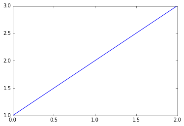

```python
fig5 = plt.figure()
ax = fig5.add_subplot(111)
ax.plot([1,2,3])
```

Now, let's remind ourselves of the standard `fig_to_plotly` result.

```python
py.iplot_mpl(fig5, resize=False, filename='no-resize', fileopt='overwrite')
```

[interactive chart not shown]

Next, we'll run the same figure, but with `resize=True`. Check out that full-width action. Stick *that* in your profile and share it.

```python
py.iplot_mpl(fig5, resize=True, filename='yes-resize', fileopt='overwrite')
```

[interactive chart not shown]

### Strip Style

Continuing to revert mpl specifications, we can aslo strip resulting JSON structures of their style. This uses the PlotlyRenderer's `strip_style` method. Just like `resize`, we can ensure that the `strip_style` method is used by passing a `strip_style=True` keyword-argument pair to `fig_to_plotly`.

Actions speak louder than words.

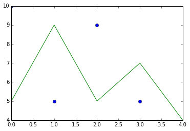

```python
fig6 = plt.figure()
ax = fig6.add_subplot(111)
ax.plot([0, 1, 2, 3], [10, 5, 9, 5], 'o')
ax.plot([5, 9, 5, 7, 4])
```

```python
import plotly.tools as tls
edited_fig = tls.mpl_to_plotly(fig6, strip_style=True)
py.iplot(edited_fig, filename='style-strip', fileopt='overwrite')
```

[interactive chart not shown]

### Bars

We like bar charts and histograms just as much as you do. Therefore, we've grabbed those for you too! Bars from bar charts are stored as 'patches' which are defined by paths. They are not, however, stored as a 'path_collection' since each bar is differently sized (or it should be unless you're making pretty boring bar charts). Plotly uses some educated guesses to decide whether rectangle patches that end up in each axes object are intended to be bar charts. When life gives you lemons, make a bar chart.

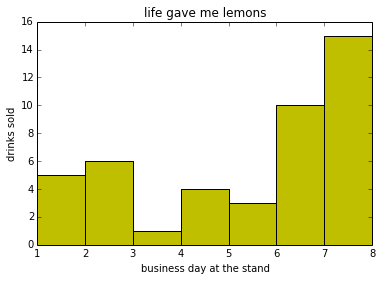

```python
fig7 = plt.figure()
ax = fig7.add_subplot(111)
left = [1, 2, 3, 4, 5, 6, 7]
height = [5, 6, 1, 4, 3, 10, 15]
width = 1
ax.bar(left, height, width=width, color='y')
ax.set_xlabel('business day at the stand')
ax.set_ylabel('drinks sold')
ax.set_title('life gave me lemons')
```

```python
py.iplot_mpl(fig7, filename='lemondade', fileopt='overwrite')
```

[interactive chart not shown]

Using mpl, we can also get horizontal bars. Let's look at an example of making some horizontal histograms.

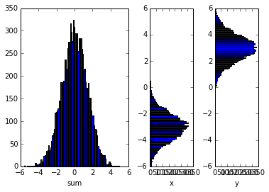

```python
fig8 = plt.figure()
y = np.random.randn(10000) + 3
x = np.random.randn(10000) - 3
sum = x + y
gs = gridspec.GridSpec(1,4)
ax1 = fig8.add_subplot(gs[0,:2])
ax1.set_xlabel('sum')
ax2 = fig8.add_subplot(gs[0,2])
ax2.set_xlabel('x')
ax2.set_ylim(-6, 6)
ax3 = fig8.add_subplot(gs[0,3])
ax3.set_xlabel('y')
ax3.set_ylim(-6, 6)
gs.update(wspace=0.5)
ax1.hist(sum, bins=100)
histx = ax2.hist(x, bins=100, orientation='horizontal')
histy = ax3.hist(y, bins=100, orientation='horizontal')
```

```python
py.iplot_mpl(fig8, filename='histograms', fileopt='overwrite')
```

[interactive chart not shown]

```python
plotly_fig = tls.mpl_to_plotly(fig8)
plotly_fig.strip_style()
py.iplot(plotly_fig)
```

[interactive chart not shown]

### Scatter

Scatter plots are a pretty common usage for matplotlib. Information about scatter plots is stored in something called a 'path_collection' which we needn't get into. The actual markers for scatter plots are stored as Bezier curves. The PlotlyRenderer will attempt to figure out what marker you've entered and import that into plotly. 'Nuff said.

Here's an example.

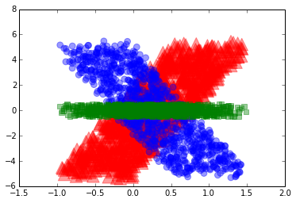

```python
fig9 = plt.figure()
ax = fig9.add_subplot(111)
num = 1000
s = 121
x1 = np.linspace(-0.5,1,num) + (0.5 - np.random.rand(num))
y1 = np.linspace(-5,5,num) + (0.5 - np.random.rand(num))
x2 = np.linspace(-0.5,1,num) + (0.5 - np.random.rand(num))
y2 = np.linspace(5,-5,num) + (0.5 - np.random.rand(num))
x3 = np.linspace(-0.5,1,num) + (0.5 - np.random.rand(num))
y3 = (0.5 - np.random.rand(num))
ax.scatter(x1, y1, color='r', s=2*s, marker='^', alpha=.4)
ax.scatter(x2, y2, color='b', s=s/2, alpha=.4)
ax.scatter(x3, y3, color='g', s=s/3, marker='s', alpha=.4)
```

```python
py.iplot_mpl(fig9, filename='scatter', fileopt='overwrite')
```

[interactive chart not shown]

```python
plotly_fig = tls.mpl_to_plotly(fig9)
plotly_fig.strip_style()
py.iplot(plotly_fig)
```

[interactive chart not shown]

### Legends

Currently, the `PlotlyRenderer` will import references to any hashable object from mpl. That is, if any part of your data was added as some sort of collection or Line2D object and you have it in a legend in mpl, it should show up in a legend on plotly.

Plotly does not yet support multiple legends in figures. Therefore, references across all legends in mpl will show up as a group in a legend on plotly. In addition, mplexporter does not support the use of `figure` legends, i.e., legends associated with the entire figure rather than with a subplot axes instance.

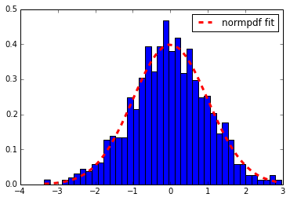

```python
from matplotlib.mlab import normpdf
fig10, ax = plt.subplots()
n, bins, patches = plt.hist(np.random.randn(1000), 40, normed=1)
l, = ax.plot(bins, normpdf(bins, 0.0, 1.0), 'r--', label='fit', linewidth=3)
leg = ax.legend([l], ['normpdf fit'])
```

```python
py.iplot_mpl(fig10, filename='bar-fit', fileopt='overwrite')
```

```
/Users/andseier/Virtualenvs/python-api/lib/python2.7/site-packages/plotly-1.0.0-py2.7.egg/plotly/matplotlylib/renderer.py:291: UserWarning: Bummer! Plotly can currently only draw Line2D objects from matplotlib that are in 'data' coordinates!
  warnings.warn("Bummer! Plotly can currently only draw Line2D "
/Users/andseier/Virtualenvs/python-api/lib/python2.7/site-packages/plotly-1.0.0-py2.7.egg/plotly/matplotlylib/renderer.py:412: UserWarning: I found a path object that I don't think is part of a bar chart. Ignoring.
  warnings.warn("I found a path object that I don't think is part "
```

[interactive chart not shown]

Also, the `PlotlyRenderer` will do its best to position the legend as specified in the mpl figure. A word of warning, when multiple legends are produced in an mpl figure, unexpected legend positions may occur in the resulting figure from the call to fig_to_plotly.

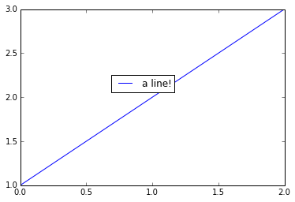

```python
fig11, ax = plt.subplots()
ax.plot([1,2,3], label='a line!')
ax.legend(bbox_to_anchor=(.5, .5,.1,.1), bbox_transform=ax.transAxes, loc=4)
```

```python
py.iplot_mpl(fig11, filename='legends', fileopt='overwrite')
```

[interactive chart not shown]

### The Nitty Gritty

Out of curiosity or for the sake of troubleshooting, you might find yourself needing to inspect the dictionaries and possibly even the mplexporter. The following shows how you go about running the PlotlyRenderer and making a manual call to plotly.

```
(90, 310)
```

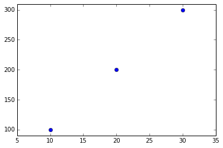

```python
fig12 = plt.figure()
ax = fig12.add_subplot(111)
ax.plot([10,20,30],[100,200,300], 'bo')
ax.set_xlim(5, 35)
ax.set_ylim(90, 310)
```

First, we will need access to the Exporter and PlotlyRenderer classes, so we import them! The Exporter crawls through the matplotlib figure, judiciously grabs pertinent information, and invokes the renderer with which it was instantiated. The PlotlyRenderer accepts calls from the Exporter and creates an appropriate JSON dictionary for use with plotly.

```python
from plotly.matplotlylib import Exporter, PlotlyRenderer
renderer = PlotlyRenderer()
exporter = Exporter(renderer)
exporter.run(fig12)
```

We can look at the resulting list of data and layout dictionaries by looking at the renderer's data and layout attributes.

```python
renderer.plotly_fig
```

```
{'data': [{'marker': {'color': '#0000FF',
    'line': {'color': '#000000', 'width': 0.5},
    'opacity': 1,
    'size': 6,
    'symbol': 'dot'},
   'mode': 'markers',
   'name': '_line0',
   'type': 'scatter',
   'x': [10.0, 20.0, 30.0],
   'y': [100.0, 200.0, 300.0]}],
 'layout': {'autosize': False,
  'height': 320,
  'hovermode': 'closest',
  'margin': {'b': 40, 'l': 60, 'pad': 0, 'r': 47, 't': 31},
  'showlegend': False,
  'width': 480,
  'xaxis': {'anchor': 'y',
   'domain': [0.0, 1.0],
   'range': (5.0, 35.0),
   'showgrid': False,
   'zeroline': False},
  'yaxis': {'anchor': 'x',
   'domain': [0.0, 1.0],
   'range': (90.0, 310.0),
   'showgrid': False,
   'zeroline': False}}}
```

Finally, to create the figure in plotly, we can call `plotly.iplot`. Again, we'll need a couple more tools from plotly, so we'll import them. We instantiate our plotly class and call it `py` by entereing our username and api_key. Then we use plotly's iplot method to drop our plot back into this IPython notebook. For more information about plotly and IPython, Plotly's [IPython docs](https://plot.ly/api/ipython) have you covered.

```python
py.iplot(renderer.plotly_fig, filename='nitty-gritty', fileopt='overwrite')
```

[interactive chart not shown]

Additionally, you can use this opportunity to add to or modify the data and layout dictionaries. Just as an example, we can change the plot and paper background colors. You might find this procedure helpful if you've snooped around the JSON drop-down in plotly on some of your favorite plots from the plotly gallery. If you see a feature you want, just add it!

```python
renderer.resize()
renderer.plotly_fig['layout']['plot_bgcolor'] = '#80adb0'
renderer.plotly_fig['layout']['paper_bgcolor'] = '#fefafd'
renderer.plotly_fig['layout']['showgridlines'] = False
py.iplot(renderer.plotly_fig)
```

[interactive chart not shown]

Follow and/or contribute to the matplotlylib progress [here](https://github.com/mpld3/matplotlylib).

Analyze and visualize data, together, with plotly [here](https://plot.ly/).